# IODS course project

Emma Dahlstrom

# About the project

*During the course we will learn how to use open data and open research tools tool. We will understand the principles, advantages and possibilities for using these open research tools (Rstudio, Github, RMarkDown). Following methods will be used during the course: Regression models, Clustering and classification, Discriminant analysis (DA), K-means clustering (KMC), Dimensionality reduction techniques, Principal component analysis (PCA), Multiple Correspondence analysis (MCA)*

# Learning Rstudio, Rmarkdown, Github

*Describe the work you have done this week and summarize your learning.*

- I have made a Github account and learned how to use it.
- My Github account is https://github.com/EmmDah/
- My course diary is https://EmmDah.github.io/IODS-project/
- My Github repository for the project https://github.com/EmmDah/IODS-project/

# Exercise 2: Regression and model validation

## Background

The dataset “students2014” contains information from 166 students attending an introductory course at the University of Helsinki. Students answered questions regarding learning approaches. The data contains 7 variables: “age”, “gender”, “attitude” (the global attitude attitude toward statistics), “deep” (higher points indicate a strong need to engage in the actual content), “stra” (higher points indicate strategies used that maximices the the chance to get a high grade) , “surf” (higher points indicate an intention to get trough with least amonut of trouble) and “points” (Exam points).

```r
students2014 <- read.table("~/GitHub/IODS-project/data/learning2018.txt", header=T, sep="\t")
dim(students2014)
```

```
## [1] 166   7
```

```r
str(students2014)
```

```
## 'data.frame':    166 obs. of  7 variables:
##  $ gender  : Factor w/ 2 levels "F","M": 1 2 1 2 2 1 2 1 2 1 ...
##  $ age     : int  53 55 49 53 49 38 50 37 37 42 ...
##  $ attitude: num  3.7 3.1 2.5 3.5 3.7 3.8 3.5 2.9 3.8 2.1 ...
##  $ deep    : num  3.58 2.92 3.5 3.5 3.67 ...
##  $ stra    : num  3.38 2.75 3.62 3.12 3.62 ...
##  $ surf    : num  2.58 3.17 2.25 2.25 2.83 ...
##  $ points  : int  25 12 24 10 22 21 21 31 24 26 ...
```

## Summary data

### Particpant summary

The summary for all variables in data is shown in table 1 and it contains the minimal and maximal value, the mean, the median and the 1st and 4th quartile for each variable. More women than men took part in the study. The average age ranged from 17 years to 55 years. The median and mean for age deviates from each other, indicating that age is not normally distributed.

```r
library(knitr)

#print a numeric summary
kable(summary(students2014), caption = "Table 1. Summary of variables in studnets2014 data")
```

Table 1. Summary of variables in studnets2014 data

|  | gender | age | attitude | deep | stra | surf | points |
| --- | --- | --- | --- | --- | --- | --- | --- |
|  | F:110 | Min. :17.00 | Min. :1.400 | Min. :1.583 | Min. :1.250 | Min. :1.583 | Min. : 7.00 |
|  | M: 56 | 1st Qu.:21.00 | 1st Qu.:2.600 | 1st Qu.:3.333 | 1st Qu.:2.625 | 1st Qu.:2.417 | 1st Qu.:19.00 |
|  | NA | Median :22.00 | Median :3.200 | Median :3.667 | Median :3.188 | Median :2.833 | Median :23.00 |
|  | NA | Mean :25.51 | Mean :3.143 | Mean :3.680 | Mean :3.121 | Mean :2.787 | Mean :22.72 |
|  | NA | 3rd Qu.:27.00 | 3rd Qu.:3.700 | 3rd Qu.:4.083 | 3rd Qu.:3.625 | 3rd Qu.:3.167 | 3rd Qu.:27.75 |
|  | NA | Max. :55.00 | Max. :5.000 | Max. :4.917 | Max. :5.000 | Max. :4.333 | Max. :33.00 |

## Distributions

Figure 1 shows the density distributions of each variable. All variables except age looks more or less normally distributed. Age is skewed.Similar distributions is noted among men and women.

## Relationships

Figure 1 also shows correlation coffiecient for the each relationship between variables and scatteplots illustrating the relationship. The strongest correlation is between attitude and points, the variables are moderately positively correlated (Cor=0.437) and similar among women and men (Figure 1 and 2). A moderate negative correlations is observed between deep and surface questions (cor -0.324), which is considerably higher among men (Men: -0.622 vs women:-0.087, Figure 1 and 3). For all other relationships, the correlation is low (<0.30).

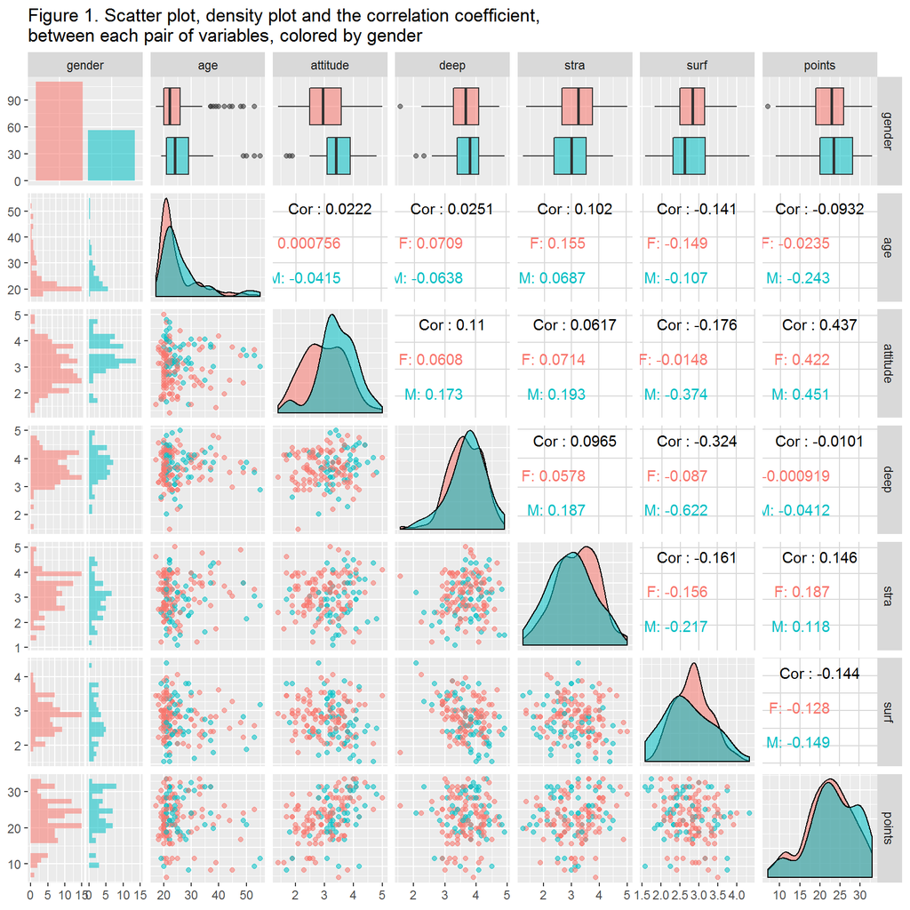

```r
library(GGally)
library(ggplot2)

#draw a graphical summary using ggpairs()
p <- ggpairs(students2014, mapping = aes(col=students2014$gender, alpha=0.3), lower = list(combo = wrap("facethist", bins = 20)))

p_final <- p+ ggtitle("Figure 1. Scatter plot, density plot and the correlation coefficient,\nbetween each pair of variables, colored by gender")
p_final
```

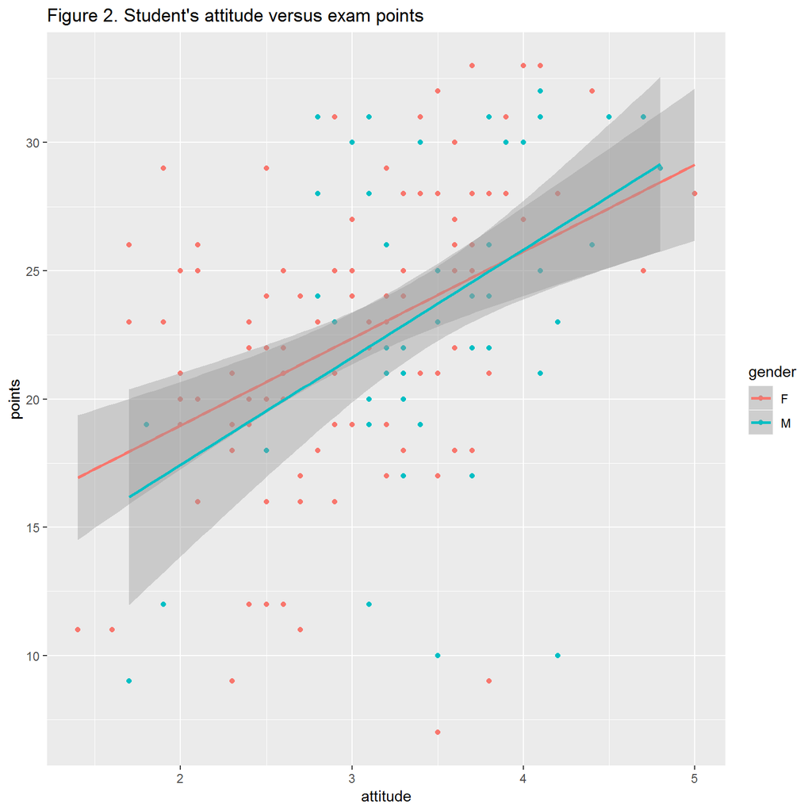

```r
# Access the gglot2 library
library(ggplot2)

# initialize plot with data and aesthetic mapping
p1 <- ggplot(students2014, aes(x = attitude, y = points, col=gender))

# define the visualization type (points), add a regression line
p2 <- p1 + geom_point() + geom_smooth(method = "lm")

# add a main title and draw the plot
p3 <- p2 + ggtitle("Figure 2. Student's attitude versus exam points")
p3
```

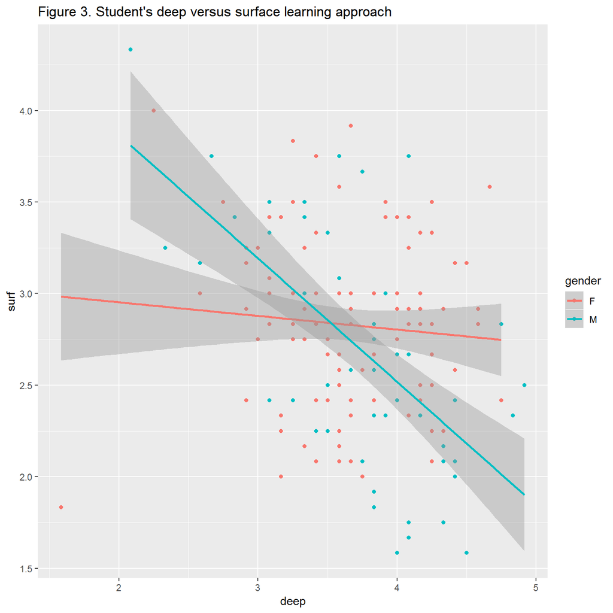

```r
# initialize plot with data and aesthetic mapping
p_1 <- ggplot(students2014, aes(x = deep, y = surf, col=gender))

# define the visualization type (points), and regression line
p_2 <- p_1 + geom_point() + geom_smooth(method = "lm")

# add a main title and draw the plot
p_3 <- p_2 + ggtitle("Figure 3. Student's deep versus surface learning approach")
p_3
```

## Linear regression

We run a linear regression to test how much attitude, age and gender explain the exam points. Of the included variables, there was only a statistically significant relationship between attitude and exam points (P=8.34e-09). Each increase 1 score increase in attitude increased the exam points by 3.6 points. Age and gender was removed from analysis, since they were did statistically significantly associate with exam points and the analysis was rerun.The attitude explained 18.56 % of the variability in Exam points.

```r
my_model <- lm(points ~ attitude+age+gender, data = students2014)

summary(my_model)
```

```
##
## Call:
## lm(formula = points ~ attitude + age + gender, data = students2014)
##
## Residuals:
##      Min       1Q   Median       3Q      Max
## -17.4590  -3.3221   0.2186   4.0247  10.4632
##
## Coefficients:
##             Estimate Std. Error t value Pr(>|t|)
## (Intercept) 13.42910    2.29043   5.863 2.48e-08 ***
## attitude     3.60657    0.59322   6.080 8.34e-09 ***
## age         -0.07586    0.05367  -1.414    0.159
## genderM     -0.33054    0.91934  -0.360    0.720
## ---
## Signif. codes:  0 '***' 0.001 '**' 0.01 '*' 0.05 '.' 0.1 ' ' 1
##
## Residual standard error: 5.315 on 162 degrees of freedom
## Multiple R-squared:  0.2018, Adjusted R-squared:  0.187
## F-statistic: 13.65 on 3 and 162 DF,  p-value: 5.536e-08
```

```r
#rerun

my_model <- lm(points ~ attitude, data = students2014)

summary(my_model)
```

```
##
## Call:
## lm(formula = points ~ attitude, data = students2014)
##
## Residuals:
##      Min       1Q   Median       3Q      Max
## -16.9763  -3.2119   0.4339   4.1534  10.6645
##
## Coefficients:
##             Estimate Std. Error t value Pr(>|t|)
## (Intercept)  11.6372     1.8303   6.358 1.95e-09 ***
## attitude      3.5255     0.5674   6.214 4.12e-09 ***
## ---
## Signif. codes:  0 '***' 0.001 '**' 0.01 '*' 0.05 '.' 0.1 ' ' 1
##
## Residual standard error: 5.32 on 164 degrees of freedom
## Multiple R-squared:  0.1906, Adjusted R-squared:  0.1856
## F-statistic: 38.61 on 1 and 164 DF,  p-value: 4.119e-09
```

## Diagnostic plots

The Residual vs fitted plot is used to detect non-linearity, unequal error variances, and outliers, which linear regression assume there is not. Based on the plot it looks like there are some outliers.

The residuals ar located quite randomly around the 0 line, which suggest that the assumption that the relationship is linear correct.

three of residual “stands out” from the pattern of residuals, suggesting there are some outliers.

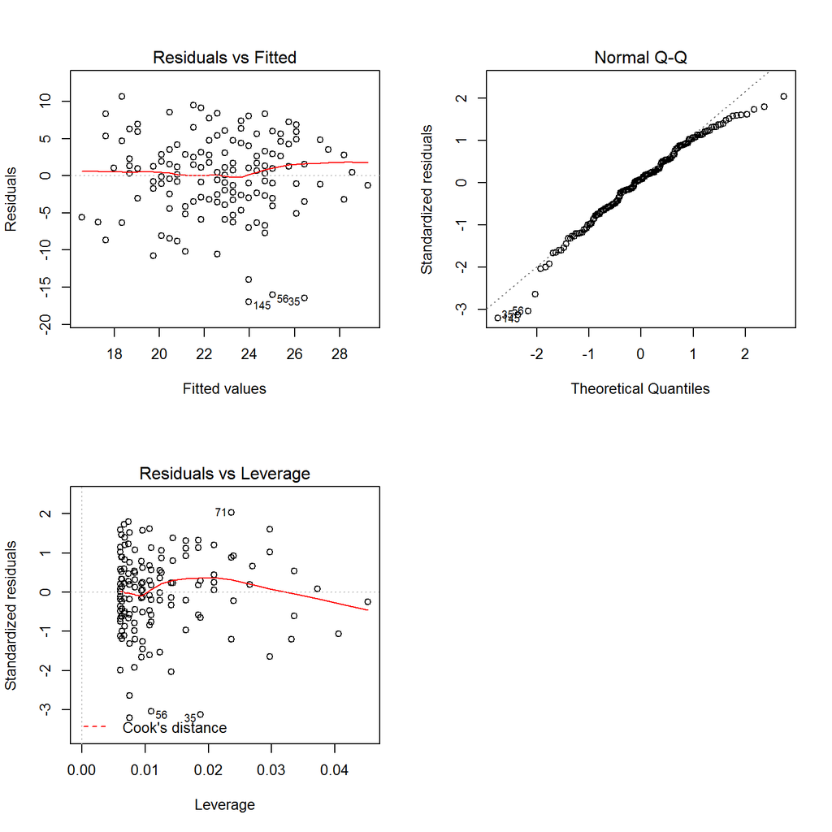

```r
par(mfrow = c(2,2))
plot(my_model, which=c(1,2,5))
```

# Exercise 3: Logistic Regression

## Background (Brief description of data)

The data is collected during the 2005-2006 school year from two public schools (secondary education) in Portugal. The data include student grades, demographic, social and school related variables, which were collected by using school reports and questionnaires.Among these is also alcohol use. Two datasets are provided regarding the performance in two distinct subjects: Mathematics (mat) and Portuguese language (por). These two have been combined into one file.

Variables G1, G2, G3 are the grades from period 1 to 3 (3 is final grade). Range is from 0-20 and an description of the range of points is in table 1.

#### Table 1.Grades in Portugal (and France)

| Excellent | Good | Satisfactory | Sufficient | Fail |
| --- | --- | --- | --- | --- |
| 16-20p | 14-15p | 12-13p | 10-11p | 0-9p |

```r
#Read the joined student alcohol consumption data into R
alc <- read.delim("~/GitHub/IODS-project/data/alc2018.txt")
dim(alc)
```

```
## [1] 382  35
```

```r
#str(alc)
#Observations: 382
#Variables: 35

#Print out the names of the variables
colnames(alc)
```

```
##  [1] "school"     "sex"        "age"        "address"    "famsize"
##  [6] "Pstatus"    "Medu"       "Fedu"       "Mjob"       "Fjob"
## [11] "reason"     "nursery"    "internet"   "guardian"   "traveltime"
## [16] "studytime"  "failures"   "schoolsup"  "famsup"     "paid"
## [21] "activities" "higher"     "romantic"   "famrel"     "freetime"
## [26] "goout"      "Dalc"       "Walc"       "health"     "absences"
## [31] "G1"         "G2"         "G3"         "alc_use"    "high_use"
```

## Personal hypotheses

I chose the following interesting variables from the datset: “sex”, “adress”" (student’s home address type, rural or urban), “famrel” (from 1 - very bad to 5 - excellent) and higher (wants to take higher education (binary: yes or no)). My personal hypotheses regarding these variables and their effect on alcohol consuption is:

Students of male sex, with poor family relationships,that don’t want to make a higher eduction and live in an urban environment drink more alcohol.

## Data exploration

Table 2a. mean value of familial relationships among high vs low users of alcohol

| high_use | count | mean_famrel |
| --- | --- | --- |
| FALSE | 268 | 4.003731 |
| TRUE | 114 | 3.780702 |

Table 2b. mean value of alcohol use among persons with a rural or urban address

| address | count | mean_alc_use |
| --- | --- | --- |
| R | 81 | 2.086420 |
| U | 301 | 1.835548 |

Table 2c. mean value of alcohol use divided by persons wanting to take higher eduction

| higher | count | mean_alc_use |
| --- | --- | --- |
| no | 18 | 2.361111 |
| yes | 364 | 1.865385 |

Table 2d. mean value of alcohol use divided by male and female

| sex | count | mean_alc_use |
| --- | --- | --- |
| F | 198 | 1.623737 |
| M | 184 | 2.173913 |

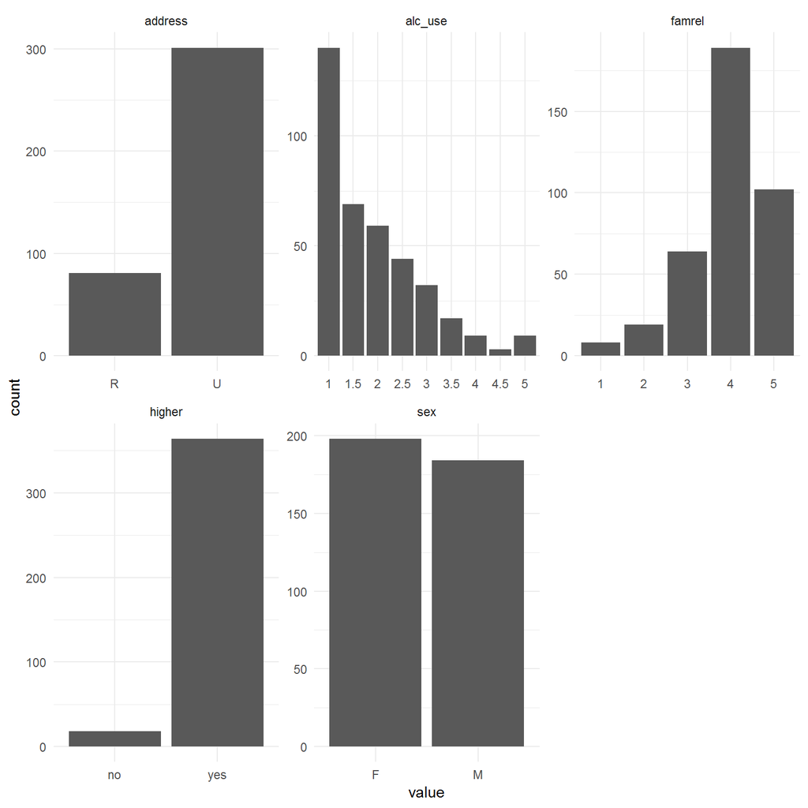

```
## [1] "Figure. 1"
```

[figure not shown]

## Logistic regression

Based on the summary of the fitted model, familial relationships are negatively associated with high alcohol use (P=0.02), having an urban address is negatively associatiod with alcohol but not on a statistically significant level (P=0.08), male sex is positively associated with high alcohol use (P=0.0002) and wanting to take a higher education is negatively associated (but not statistically significant!) with high alcohol use. The z- and p-values are based on the wald test, which is used in the model to test whether the pairwise difference between the coefficient and the reference class and the other class is different from zero or not (categorical values).

```r
glm_res <- glm(high_use ~ famrel + address +sex+higher, data = alc, family = "binomial")
library(knitr)
#summary of the model
summary(glm_res)
```

```
##
## Call:
## glm(formula = high_use ~ famrel + address + sex + higher, family = "binomial",
##     data = alc)
##
## Deviance Residuals:
##    Min      1Q  Median      3Q     Max
## -1.505  -0.832  -0.638   1.192   1.973
##
## Coefficients:
##             Estimate Std. Error z value Pr(>|z|)
## (Intercept)   0.7675     0.7188   1.068 0.285623
## famrel       -0.3028     0.1256  -2.410 0.015947 *
## addressU     -0.4748     0.2718  -1.747 0.080616 .
## sexM          0.8845     0.2375   3.725 0.000196 ***
## higheryes    -0.5701     0.4981  -1.145 0.252387
## ---
## Signif. codes:  0 '***' 0.001 '**' 0.01 '*' 0.05 '.' 0.1 ' ' 1
##
## (Dispersion parameter for binomial family taken to be 1)
##
##     Null deviance: 465.68  on 381  degrees of freedom
## Residual deviance: 440.35  on 377  degrees of freedom
## AIC: 450.35
##
## Number of Fisher Scoring iterations: 4
```

```r
#OR and 95%CIs
ORs_CI <-cbind(t(t(exp(coef(glm_res)))), exp(confint.default(glm_res)))
colnames(ORs_CI)[1] <- "OR"
kable(ORs_CI, caption = "Table 3. Odds Ratio and 95%CI")
```

Table 3. Odds Ratio and 95%CI

|  | OR | 2.5 % | 97.5 % |
| --- | --- | --- | --- |
| (Intercept) | 2.1543339 | 0.5266187 | 8.8131204 |
| famrel | 0.7387682 | 0.5775324 | 0.9450178 |
| addressU | 0.6220032 | 0.3651443 | 1.0595481 |
| sexM | 2.4218136 | 1.5205221 | 3.8573469 |
| higheryes | 0.5654463 | 0.2130030 | 1.5010564 |

## The predictive power of the model

A 2x2 cross tabulation of predictions versus the actual values is found in tables and a graphic visualizing both the actual values and the predictions is in figure 4. 106 observations are predicted as false, even though they are true high users of alcohol (264 persons correctly predicted as non high alcohol users). Only 4 persons are falsely predicted as high alc users even though they are not, 8 persons are predicted correctly as high alc users. Model good at predicting non-high users, not so good at predicting high-users. The total proportion of inaccurately classified individuals (= the training error) is found in last table. Base on that table:

- 69% is correctly identifed as non-high users
- 2% correctly identified as high users.
- 1% non-high users uncorrectly identified as high users
- 28% high users uncorrectly identified as non high users

However, 71% is correctly identified, se better than guessing!

The average number of wrong predictions in the training data was 0.28

```r
library(dplyr)
#fit a logistic regression with my sig variables
glm_res2 <- glm(high_use ~ famrel+sex, data = alc, family = "binomial")

#predict probability of high use
probabilities <- predict(glm_res2, type = "response")

# add the predicted probabilities to 'alc'
alc <- mutate(alc, probability = probabilities)

# use the probabilities to make a prediction of high_use
alc <- mutate(alc, prediction = probability > 0.5)

# see the last ten original classes, predicted probabilities, and class predictions
select(alc, famrel, sex, high_use, probability, prediction) %>% tail(10)
```

```
##     famrel sex high_use probability prediction
## 373      4   M    FALSE   0.3897160      FALSE
## 374      5   M     TRUE   0.3188820      FALSE
## 375      5   F    FALSE   0.1567208      FALSE
## 376      4   F    FALSE   0.2022285      FALSE
## 377      5   F    FALSE   0.1567208      FALSE
## 378      4   F    FALSE   0.2022285      FALSE
## 379      2   F    FALSE   0.3204713      FALSE
## 380      1   F    FALSE   0.3914555      FALSE
## 381      2   M     TRUE   0.5429715       TRUE
## 382      4   M     TRUE   0.3897160      FALSE
```

```r
# tabulate the target variable versus the predictions
table(high_use = alc$high_use, prediction = alc$prediction)
```

```
##         prediction
## high_use FALSE TRUE
##    FALSE   264    4
##    TRUE    106    8
```

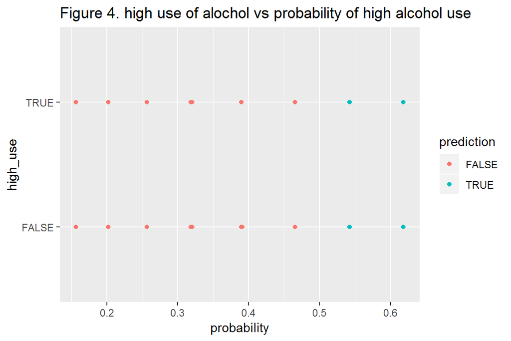

```r
# access dplyr and ggplot2
library(dplyr); library(ggplot2)

# initialize a plot of 'high_use' versus 'probability' in 'alc'
g <- ggplot(alc, aes(x = probability, y = high_use,col=prediction))

# define the geom as points and draw the plot
g +geom_point()+ggtitle("Figure 4. high use of alochol vs probability of high alcohol use")
```

```r
# tabulate the target variable versus the predictions
table(high_use = alc$high_use, prediction = alc$prediction)
```

```
##         prediction
## high_use FALSE TRUE
##    FALSE   264    4
##    TRUE    106    8
```

```r
table(high_use = alc$high_use, prediction = alc$prediction)  %>% prop.table() %>% addmargins()
```

```
##         prediction
## high_use      FALSE       TRUE        Sum
##    FALSE 0.69109948 0.01047120 0.70157068
##    TRUE  0.27748691 0.02094241 0.29842932
##    Sum   0.96858639 0.03141361 1.00000000
```

```r
# define a loss function (average prediction error)
loss_func <- function(class, prob) {
  n_wrong <- abs(class - prob) > 0.5
  mean(n_wrong)
}

# call loss_func to compute the average number of wrong predictions in the (training) data
loss_func(class = alc$high_use, prob = alc$probability)
```

```
## [1] 0.2879581
```

## 10-fold Cross-validation

COMMENT TO EVALUATOR: DONT EVALUATE THIS STEP! SUBMITTED AFTER DEADLINE (did not have time to make the bonus step before deadline but wanted to do it still) Bonus: Perform 10-fold cross-validation on your model.

My model has a worse test set performance, the prediction error is 0.29, which is larger than 0.26 (in Datacamp exercise).

```r
# the logistic regression model m and dataset alc (with predictions) are available

# define a loss function (average prediction error)
loss_func <- function(class, prob) {
  n_wrong <- abs(class - prob) > 0.5
  mean(n_wrong)
}

# compute the average number of wrong predictions in the (training) data
loss_func(class = alc$high_use, prob = alc$probability)
```

```
## [1] 0.2879581
```

```r
# 10-fold cross-validation on your model:
library(boot)
nrow(alc)
```

```
## [1] 382
```

```r
cv <- cv.glm(data = alc, cost = loss_func, glmfit = glm_res2, K = 10)

# average number of wrong predictions in the cross validation
cv$delta[1]
```

```
## [1] 0.2879581
```

# Exercise 4:Clustering and classification

## Description of data

In step 1 I created a new chapter called chapter 4. The MASS library contains the Boston data set, which has 506 obs. of 14 variables. The 506 observations are records (housing values) for 506 neighborhoods (suburbs) around Boston.The following 14 variables are included in Boston:

- crim : num per capita crime rate by town.
- zn : num proportion of residential land zoned for lots over 25,000 sq.ft
- indus : num proportion of non-retail business acres per town.
- chas : int Charles River dummy variable (= 1 if tract bounds river; 0 otherwise)
- nox : num nitrogen oxides concentration (parts per 10 million).
- rm : num average number of rooms per dwelling.
- age : num proportion of owner-occupied units built prior to 1940..
- dis : num weighted mean of distances to five Boston employment centres.
- rad : int index of accessibility to radial highways..
- tax : num full-value property-tax rate per $10,000.
- ptratio: num pupil-teacher ratio by town..
- black : num 1000(Bk - 0.63)^2 where Bk is the proportion of blacks by town.
- lstat : num lower status of the population (percent)..
- medv : num median value of owner-occupied homes in $1000s.

```r
##Load the Boston data from the MASS package
library(MASS)
data(Boston)
##structure of Boston data
str(Boston)
```

```
## 'data.frame':    506 obs. of  14 variables:
##  $ crim   : num  0.00632 0.02731 0.02729 0.03237 0.06905 ...
##  $ zn     : num  18 0 0 0 0 0 12.5 12.5 12.5 12.5 ...
##  $ indus  : num  2.31 7.07 7.07 2.18 2.18 2.18 7.87 7.87 7.87 7.87 ...
##  $ chas   : int  0 0 0 0 0 0 0 0 0 0 ...
##  $ nox    : num  0.538 0.469 0.469 0.458 0.458 0.458 0.524 0.524 0.524 0.524 ...
##  $ rm     : num  6.58 6.42 7.18 7 7.15 ...
##  $ age    : num  65.2 78.9 61.1 45.8 54.2 58.7 66.6 96.1 100 85.9 ...
##  $ dis    : num  4.09 4.97 4.97 6.06 6.06 ...
##  $ rad    : int  1 2 2 3 3 3 5 5 5 5 ...
##  $ tax    : num  296 242 242 222 222 222 311 311 311 311 ...
##  $ ptratio: num  15.3 17.8 17.8 18.7 18.7 18.7 15.2 15.2 15.2 15.2 ...
##  $ black  : num  397 397 393 395 397 ...
##  $ lstat  : num  4.98 9.14 4.03 2.94 5.33 ...
##  $ medv   : num  24 21.6 34.7 33.4 36.2 28.7 22.9 27.1 16.5 18.9 ...
```

```r
##dimensions of Boston data
dim(Boston)
```

```
## [1] 506  14
```

## Data exploration

### Numerical summary of data

The summary of the variables in the data is shown below. Based on the large differences between mean and median of values of “black”, “tax”, “rad”,“age”, “indus”, “zn” and “crim”, looks like the distribution of these are skewed.

```r
library(MASS);library(knitr)
(summary(Boston))
```

```
##       crim                zn             indus            chas
##  Min.   : 0.00632   Min.   :  0.00   Min.   : 0.46   Min.   :0.00000
##  1st Qu.: 0.08204   1st Qu.:  0.00   1st Qu.: 5.19   1st Qu.:0.00000
##  Median : 0.25651   Median :  0.00   Median : 9.69   Median :0.00000
##  Mean   : 3.61352   Mean   : 11.36   Mean   :11.14   Mean   :0.06917
##  3rd Qu.: 3.67708   3rd Qu.: 12.50   3rd Qu.:18.10   3rd Qu.:0.00000
##  Max.   :88.97620   Max.   :100.00   Max.   :27.74   Max.   :1.00000
##       nox               rm             age              dis
##  Min.   :0.3850   Min.   :3.561   Min.   :  2.90   Min.   : 1.130
##  1st Qu.:0.4490   1st Qu.:5.886   1st Qu.: 45.02   1st Qu.: 2.100
##  Median :0.5380   Median :6.208   Median : 77.50   Median : 3.207
##  Mean   :0.5547   Mean   :6.285   Mean   : 68.57   Mean   : 3.795
##  3rd Qu.:0.6240   3rd Qu.:6.623   3rd Qu.: 94.08   3rd Qu.: 5.188
##  Max.   :0.8710   Max.   :8.780   Max.   :100.00   Max.   :12.127
##       rad              tax           ptratio          black
##  Min.   : 1.000   Min.   :187.0   Min.   :12.60   Min.   :  0.32
##  1st Qu.: 4.000   1st Qu.:279.0   1st Qu.:17.40   1st Qu.:375.38
##  Median : 5.000   Median :330.0   Median :19.05   Median :391.44
##  Mean   : 9.549   Mean   :408.2   Mean   :18.46   Mean   :356.67
##  3rd Qu.:24.000   3rd Qu.:666.0   3rd Qu.:20.20   3rd Qu.:396.23
##  Max.   :24.000   Max.   :711.0   Max.   :22.00   Max.   :396.90
##      lstat            medv
##  Min.   : 1.73   Min.   : 5.00
##  1st Qu.: 6.95   1st Qu.:17.02
##  Median :11.36   Median :21.20
##  Mean   :12.65   Mean   :22.53
##  3rd Qu.:16.95   3rd Qu.:25.00
##  Max.   :37.97   Max.   :50.00
```

### Graphical overview of the distributions

Figure 1 shows a graphical summary of the distribution of all variables in the dataset.Based on that:

Many of the variables are skewed, comments on a few variables * Age (prportion of houses build before 1940) is skewed and there is proportionally more suburbs with older houses in the dataset. * Crime rate is skewed (crim), looks like most suburbs have crime rate close to 0, but a few has really high. * The distribution of the accessibility to radial highways (rad) the proprtion of non-retail business (indus) and the tax rates (tax) are bimodial.

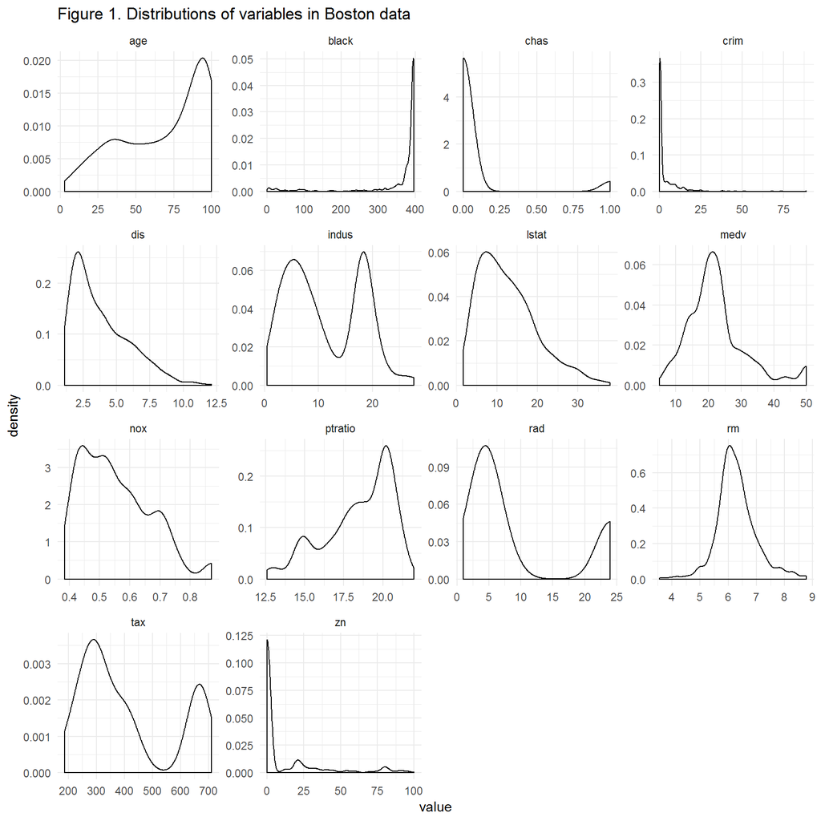

```r
library(ggplot2);library(dplyr);library(tidyr)
gather(Boston) %>% ggplot() + geom_density(aes(value)) + facet_wrap("key", scales = "free")+theme_minimal()+ggtitle("Figure 1. Distributions of variables in Boston data")
```

### Relationships in the data

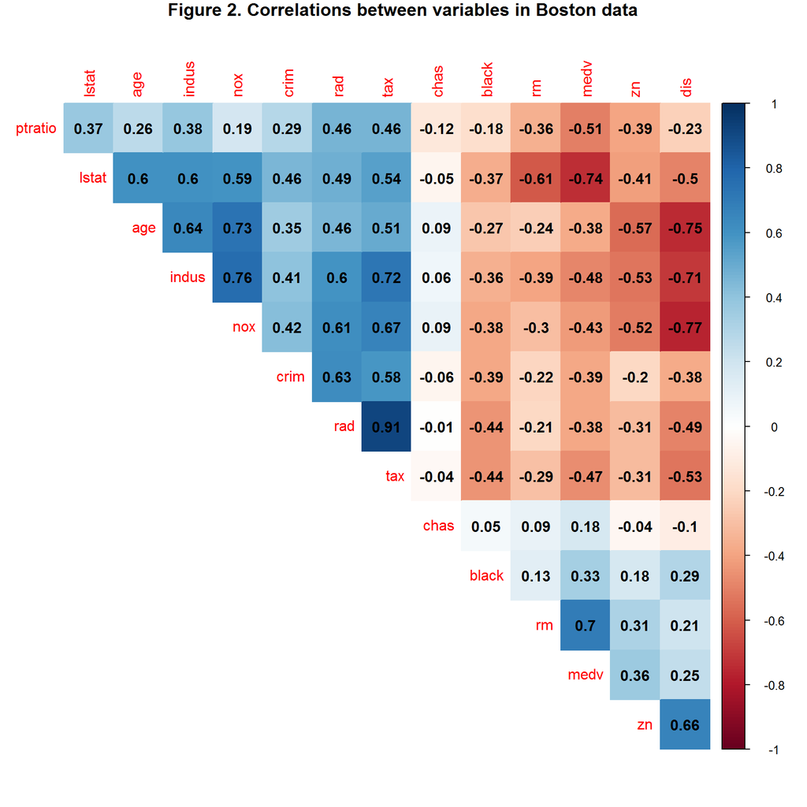

```r
library(tidyverse);library(MASS);library(corrplot)
# MASS, corrplot, tidyverse and Boston dataset are available

# calculate the correlation matrix
cor_matrix<-cor(Boston)

# visualize the correlation matrix
corrplot(cor_matrix, method="color",
     diag=FALSE,
     type="upper",
     order="hclust",
     title="Figure 2. Correlations between variables in Boston data",
     addCoef.col = "black", # Add coefficient of correlation
     mar=c(0,0,1,0)
     )
```

## Standardization

Whole dataset Boston was Standardized using scale(), summaries of the scaled data are shown below. SCale() subtract the mean and divide by the standard deviation of your variable. The result will have mean=0 and sd=1.The means and variances of all variables are now the same.

```r
library(MASS);library(dplyr); library(knitr)
# MASS and Boston dataset are available

# center and standardize variables
boston_scaled <- scale(Boston)

# summaries of the scaled variables
summary(boston_scaled)
```

```
##       crim                 zn               indus
##  Min.   :-0.419367   Min.   :-0.48724   Min.   :-1.5563
##  1st Qu.:-0.410563   1st Qu.:-0.48724   1st Qu.:-0.8668
##  Median :-0.390280   Median :-0.48724   Median :-0.2109
##  Mean   : 0.000000   Mean   : 0.00000   Mean   : 0.0000
##  3rd Qu.: 0.007389   3rd Qu.: 0.04872   3rd Qu.: 1.0150
##  Max.   : 9.924110   Max.   : 3.80047   Max.   : 2.4202
##       chas              nox                rm               age
##  Min.   :-0.2723   Min.   :-1.4644   Min.   :-3.8764   Min.   :-2.3331
##  1st Qu.:-0.2723   1st Qu.:-0.9121   1st Qu.:-0.5681   1st Qu.:-0.8366
##  Median :-0.2723   Median :-0.1441   Median :-0.1084   Median : 0.3171
##  Mean   : 0.0000   Mean   : 0.0000   Mean   : 0.0000   Mean   : 0.0000
##  3rd Qu.:-0.2723   3rd Qu.: 0.5981   3rd Qu.: 0.4823   3rd Qu.: 0.9059
##  Max.   : 3.6648   Max.   : 2.7296   Max.   : 3.5515   Max.   : 1.1164
##       dis               rad               tax             ptratio
##  Min.   :-1.2658   Min.   :-0.9819   Min.   :-1.3127   Min.   :-2.7047
##  1st Qu.:-0.8049   1st Qu.:-0.6373   1st Qu.:-0.7668   1st Qu.:-0.4876
##  Median :-0.2790   Median :-0.5225   Median :-0.4642   Median : 0.2746
##  Mean   : 0.0000   Mean   : 0.0000   Mean   : 0.0000   Mean   : 0.0000
##  3rd Qu.: 0.6617   3rd Qu.: 1.6596   3rd Qu.: 1.5294   3rd Qu.: 0.8058
##  Max.   : 3.9566   Max.   : 1.6596   Max.   : 1.7964   Max.   : 1.6372
##      black             lstat              medv
##  Min.   :-3.9033   Min.   :-1.5296   Min.   :-1.9063
##  1st Qu.: 0.2049   1st Qu.:-0.7986   1st Qu.:-0.5989
##  Median : 0.3808   Median :-0.1811   Median :-0.1449
##  Mean   : 0.0000   Mean   : 0.0000   Mean   : 0.0000
##  3rd Qu.: 0.4332   3rd Qu.: 0.6024   3rd Qu.: 0.2683
##  Max.   : 0.4406   Max.   : 3.5453   Max.   : 2.9865
```

```r
# class of the boston_scaled object
class(boston_scaled)
```

```
## [1] "matrix"
```

```r
# change the object to data frame
boston_scaled <- as.data.frame(boston_scaled)

#make quantiles of crim rate in scaled boston data
bins <- quantile(boston_scaled$crim)
#check values of bin
bins
```

```
##           0%          25%          50%          75%         100%
## -0.419366929 -0.410563278 -0.390280295  0.007389247  9.924109610
```

```r
#based on the quatnile values made the new variable crim
crime <- cut(boston_scaled$crim, breaks = bins, include.lowest = TRUE)

#variable looks good, quite equal group sizes, 4 quantiles
kable(table(crime), caption="Table 1.crim rate ranges (min-max) in quantile groups (and N)")
```

Table 1.crim rate ranges (min-max) in quantile groups (and N)

| crime | Freq |
| --- | --- |
| [-0.419,-0.411] | 127 |
| (-0.411,-0.39] | 126 |
| (-0.39,0.00739] | 126 |
| (0.00739,9.92] | 127 |

```r
crime <- cut(boston_scaled$crim, breaks = bins, include.lowest = TRUE,
             label=c("low","med_low","med_high","high"))

kable(table(crime), caption = "Table 2. Names of crime rates quantile groups (and N)")
```

Table 2. Names of crime rates quantile groups (and N)

| crime | Freq |
| --- | --- |
| low | 127 |
| med_low | 126 |
| med_high | 126 |
| high | 127 |

```r
#remove crim (not crime)
boston_scaled <- dplyr::select(boston_scaled, -crim)
#new variable crime added to dataset
boston_scaled <- data.frame(boston_scaled, crime)

#Dividing the data set into train (80% of data) and test
n <- nrow(boston_scaled)
#randomly selected indivials 80%
ind <- sample(n,  size = n * 0.8)
#training set
train <- boston_scaled[ind,]
# create test set
test <- boston_scaled[-ind,]
```

## Linear discriminant analysis

Fited the linear discriminant analysis on the train set. Used the categorical crime rate as the target variable and all the other variables in the dataset as predictor variables. Figure 3 shows the LDA (bi)plot.

About linear discriminant analysis: Target variable is categorical and this classification method tries to find the variables (or finds the (linear) combination of the variables) that disciminate/sepratate the classes/groups in the target variable best.But it can be also used to predict classes in the new data. Assumptions: variables are normally distributed, variables have same variance and that is the reasons variables were scaled previously

```r
#lda of trained data
lda.fit <- lda(crime~ ., data = train)
lda.fit
```

```
## Call:
## lda(crime ~ ., data = train)
##
## Prior probabilities of groups:
##       low   med_low  med_high      high
## 0.2599010 0.2698020 0.2351485 0.2351485
##
## Group means:
##                   zn      indus        chas        nox          rm
## low       0.93628074 -0.9507796 -0.12234430 -0.8854313  0.40111785
## med_low  -0.07026987 -0.2895896  0.01663242 -0.5749389 -0.11471068
## med_high -0.41322071  0.1651074  0.14210254  0.2968620  0.05064873
## high     -0.48724019  1.0172655 -0.06511327  1.0164048 -0.37527762
##                 age        dis        rad        tax     ptratio
## low      -0.8878189  0.9446844 -0.6898324 -0.7238141 -0.41453161
## med_low  -0.3206948  0.3873816 -0.5467181 -0.4965476 -0.07014674
## med_high  0.3431323 -0.3055854 -0.4052199 -0.3147537 -0.12678424
## high      0.8167796 -0.8554512  1.6366336  1.5129868  0.77903654
##                black       lstat         medv
## low       0.37533605 -0.76338076  0.444400067
## med_low   0.31907907 -0.13180511 -0.008754141
## med_high  0.09648401  0.02144601  0.094862125
## high     -0.75336606  0.83555172 -0.657319722
##
## Coefficients of linear discriminants:
##                 LD1         LD2         LD3
## zn       0.07142265  0.76214764 -0.77118383
## indus    0.05789593 -0.42603113  0.47310841
## chas    -0.08247107 -0.08447138  0.06945964
## nox      0.33906898 -0.57529823 -1.67394604
## rm      -0.09258823 -0.06026355 -0.20086596
## age      0.24845141 -0.23065558 -0.06853682
## dis     -0.05176116 -0.28782066  0.11656146
## rad      3.05270877  0.94966794  0.19726697
## tax      0.07092454  0.03135834  0.36617752
## ptratio  0.12723955 -0.06562721 -0.28972037
## black   -0.12124451 -0.00122400  0.11323098
## lstat    0.21696034 -0.26166892  0.35687003
## medv     0.19906224 -0.36168740 -0.23467284
##
## Proportion of trace:
##    LD1    LD2    LD3
## 0.9498 0.0374 0.0128
```

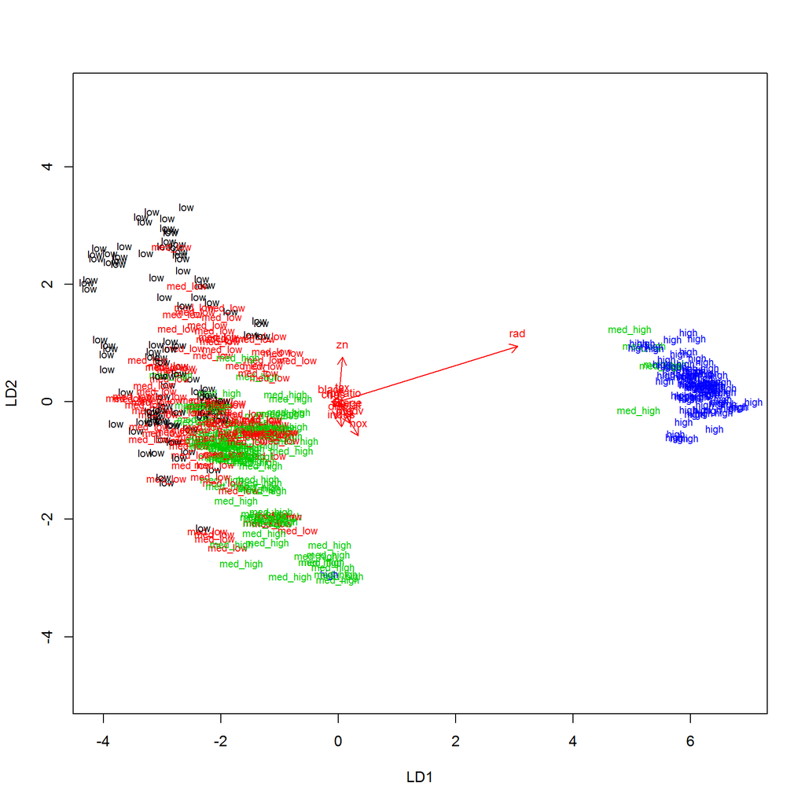

Figure 3. LDA plot

```r
# the function for lda biplot arrows
lda.arrows <- function(x, myscale = 1, arrow_heads = 0.1, color = "red", tex = 0.75, choices = c(1,2)){
  heads <- coef(x)
  arrows(x0 = 0, y0 = 0,
         x1 = myscale * heads[,choices[1]],
         y1 = myscale * heads[,choices[2]], col=color, length = arrow_heads)
  text(myscale * heads[,choices], labels = row.names(heads),
       cex = tex, col=color, pos=3)
}

# target classes as numeric
classes <- as.numeric(train$crime)

# plot the lda results
plot(lda.fit, dimen = 2, col = classes, pch = classes)
lda.arrows(lda.fit, myscale = 1)
```

## Predict crime classes in test using LDA

The classes was predicted with the LDA model on the test data. In the Cross you can see the results with the crime categories from the test set. Based on that you can see:

```r
library(MASS)
#classe from
correct_classes <- test$crime
test <- dplyr::select(test, -crime)
lda.fit <- lda(crime~ ., data = train)
lda.pred <- predict(lda.fit, newdata = test)


table(correct = correct_classes, predicted = lda.pred$class)
```

```
##           predicted
## correct    low med_low med_high high
##   low       13       6        3    0
##   med_low    2      14        1    0
##   med_high   2       4       24    1
##   high       0       0        0   32
```

## K-means clustering

There are different ways to determine if observations are similar or dissimilar to each other. Distance measure can be used for this, and I used dist(), which has as default the most common distance measure the Euclidean distance. The distances were saved to object “dist_eu”. After distances were calculated k-means was run on the dataset. K-means is easy and often find a solution, however a small change in the dataset can produce a very different result.

First how the total of within cluster sum of squares (WCSS). When you plot the number of clusters and the total WCSS, the optimal number of clusters is when the total WCSS drops radically. The optimal numbers of clusters is 2, according to figure below.

I find it really hard to interpret the results otherwise. But some of the variables show similar patterns, for example nox rm and age seem to cluster.

```r
##Reload the Boston dataset and standardize
library(MASS);library(ggplot2)
data('Boston')
boston_scaled2 <- as.data.frame(scale(Boston))


##Calculate the distances between the observations (Euclidian)
dist_eu <-dist(boston_scaled2)
summary(dist_eu)
```

```
##    Min. 1st Qu.  Median    Mean 3rd Qu.    Max.
##  0.1343  3.4625  4.8241  4.9111  6.1863 14.3970
```

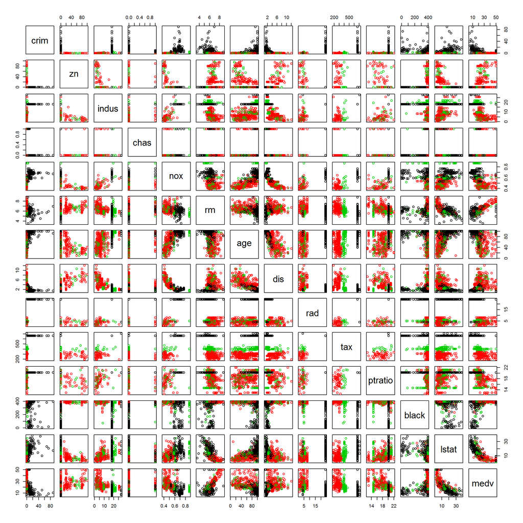

```r
##Run k-means algorithm on the dataset
# k-means clustering
km <-kmeans(Boston, centers = 3)

# plot the Boston dataset with clusters
pairs(Boston, col = km$cluster)
```

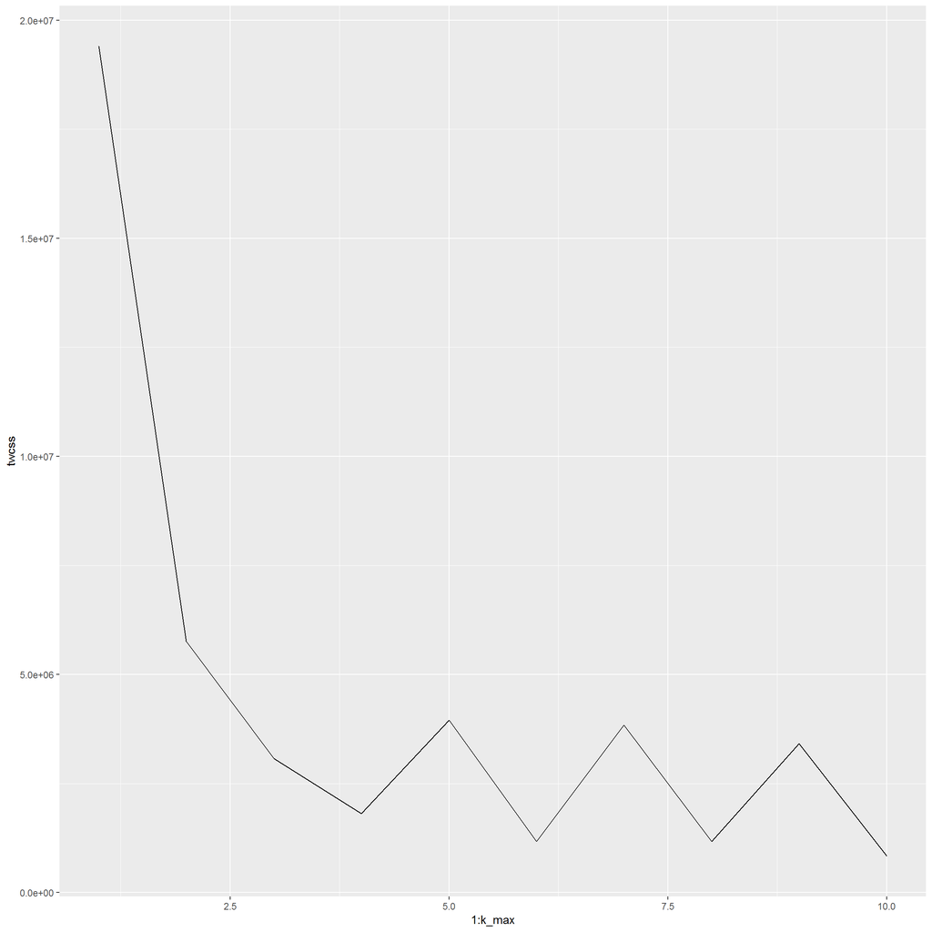

```r
set.seed(123)

# determine the number of clusters
k_max <- 10

# calculate the total within sum of squares
twcss <- sapply(1:k_max, function(k){kmeans(Boston, k)$tot.withinss})

# visualize the results
qplot(x = 1:k_max, y = twcss, geom = 'line')
```

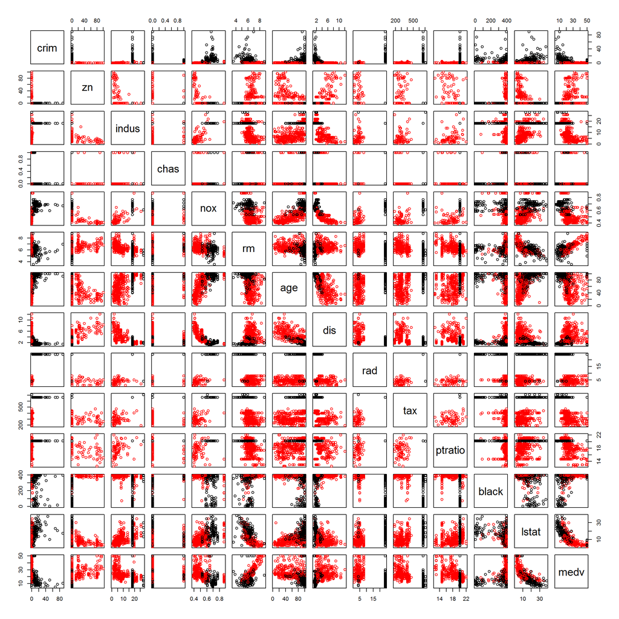

```r
# k-means clustering
km <-kmeans(Boston, centers = 2)

# plot the Boston dataset with clusters
pairs(Boston, col = km$cluster)
```

# Exercise 5: Dimensionality reduction techniques

## Data exploration

### Numerical summaries and distributions

Based on numerical summary below (escpecially the means and the medians), and the the diagnoally located density distributions in figure 1, we can see that:

–> Some of the distributions are skewed. The variables that are the most skewed are *GNI* and *maternal mortality*

```r
human <- read.delim("~/GitHub/IODS-project/data/human_new_2018.txt")
summary(human)
```

```
##     Edu2.FM          Labo.FM          Edu.Exp         Life.Exp
##  Min.   :0.1717   Min.   :0.1857   Min.   : 5.40   Min.   :49.00
##  1st Qu.:0.7264   1st Qu.:0.5984   1st Qu.:11.25   1st Qu.:66.30
##  Median :0.9375   Median :0.7535   Median :13.50   Median :74.20
##  Mean   :0.8529   Mean   :0.7074   Mean   :13.18   Mean   :71.65
##  3rd Qu.:0.9968   3rd Qu.:0.8535   3rd Qu.:15.20   3rd Qu.:77.25
##  Max.   :1.4967   Max.   :1.0380   Max.   :20.20   Max.   :83.50
##       GNI            Mat.Mor         Ado.Birth         Parli.F
##  Min.   :   581   Min.   :   1.0   Min.   :  0.60   Min.   : 0.00
##  1st Qu.:  4198   1st Qu.:  11.5   1st Qu.: 12.65   1st Qu.:12.40
##  Median : 12040   Median :  49.0   Median : 33.60   Median :19.30
##  Mean   : 17628   Mean   : 149.1   Mean   : 47.16   Mean   :20.91
##  3rd Qu.: 24512   3rd Qu.: 190.0   3rd Qu.: 71.95   3rd Qu.:27.95
##  Max.   :123124   Max.   :1100.0   Max.   :204.80   Max.   :57.50
```

### Relationships between variables

The variables in the dataset human are quite correlated.In Figure 1 you can (see besides the distributions) the correlations and the relationships between each variable in the dataset human. From the figure we conclude see that:

*Maternal mortality:*

- High negative correlation with Exp.Life and Exp.Edu and GNI, so When life expectansy (r2=-0.86) and expected education (-0.74) increase, maternal mortality decreases. Life expectansy and expected education are highly positively correlated to each other as well (r2=0.79)
- High postive correlation with adoscesent birt rate (r2=0.76) so when adolescent birth rate increse the maternal mortality rate increases.

*GNI:*

- We also se that the GNI, National Gross income increases with increasing life expectansy and expected education, and decreases with higher maternal mortality rates and adolescent birth rates.
- Still worth mentioning of these is the drecrease in maternal mortality and increse in GNI with higher education in women.

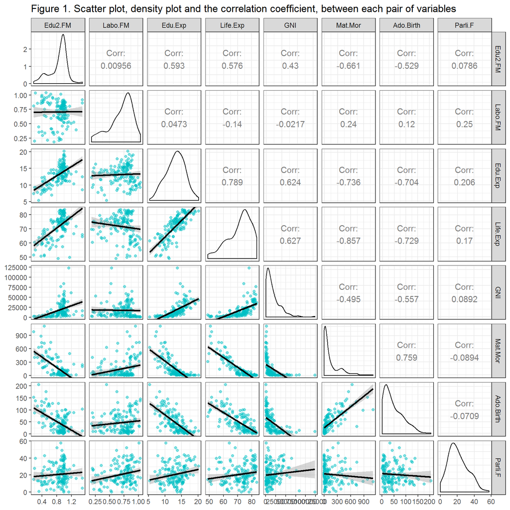

```r
library(GGally)
library(ggplot2)
library(corrplot)


#draw a graphical summary using ggpairs()
#?ggpairs()
p <- ggpairs(human, lower=list(continuous=wrap("smooth", colour="#00BFC4", alpha=0.5),combo = wrap("facethist", bins = 20)), title ="Figure 1. Scatter plot, density plot and the correlation coefficient, between each pair of variables")

p+theme_bw()
```

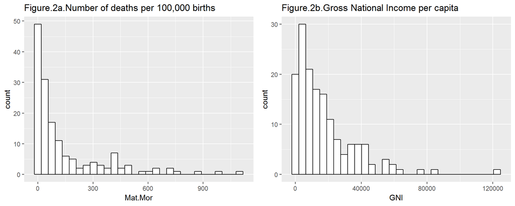

```r
library(ggpubr);library(ggplot2);library(dplyr);library(knitr)

## make a separate histogram of GNI, difficult to se x axis in fig 1
g1 <- ggplot(human, aes(x=GNI)) +
    geom_histogram(colour="black", fill="white")+ggtitle("Figure.2b.Gross National Income per capita")
g2 <- ggplot(human, aes(x=Mat.Mor)) +
    geom_histogram(colour="black", fill="white")+ggtitle("Figure.2a.Number of deaths per 100,000 births")

ggarrange(g2, g1, nrow=1, ncol = 2)
```

```r
#Check which countries has high Mat. mor
kable(subset(human, Mat.Mor > 800), caption="Table 1. Countries where maternal mortality is over 800 deaths per 100,000 births")
```

Table 1. Countries where maternal mortality is over 800 deaths per 100,000 births

|  | Edu2.FM | Labo.FM | Edu.Exp | Life.Exp | GNI | Mat.Mor | Ado.Birth | Parli.F |
| --- | --- | --- | --- | --- | --- | --- | --- | --- |
| Sierra Leone | 0.4608295 | 0.9521739 | 8.6 | 50.9 | 1780 | 1100 | 100.7 | 12.4 |
| Chad | 0.1717172 | 0.8080808 | 7.4 | 51.6 | 2085 | 980 | 152.0 | 14.9 |
| Central African Republic | 0.3782772 | 0.8531140 | 7.2 | 50.7 | 581 | 880 | 98.3 | 12.5 |

```r
#Check which countries has high GNI
kable(subset(human, GNI > 70000), caption="Table 1. Countries where GNI is over 70,000$")
```

Table 1. Countries where GNI is over 70,000$

|  | Edu2.FM | Labo.FM | Edu.Exp | Life.Exp | GNI | Mat.Mor | Ado.Birth | Parli.F |
| --- | --- | --- | --- | --- | --- | --- | --- | --- |
| Singapore | 0.9148148 | 0.7616580 | 15.4 | 83.0 | 76628 | 6 | 6.0 | 25.3 |
| Qatar | 1.1305085 | 0.5319372 | 13.8 | 78.2 | 123124 | 6 | 9.5 | 0.0 |
| Kuwait | 0.9875666 | 0.5246691 | 14.7 | 74.4 | 83961 | 14 | 14.5 | 1.5 |

## Principal component analysis (PCA)

Performed PCA with unscaled data. As shown below, PC1 capture 100% of the variablility in the dataset. Other variables capture none.If we look at the biplot (figure 3), it does not loo good. We only see an arrow for GNI.

```r
#Run principal component analysis (PCA)
# perform principal component analysis (with the SVD method)
pca_human <- prcomp(human)
# the variability captured by the principal components
# create and print out a summary of pca_human
# create and print out a summary of pca_human
s <- summary(pca_human)
s
```

```
## Importance of components:
##                              PC1      PC2   PC3   PC4   PC5   PC6    PC7
## Standard deviation     1.854e+04 185.5219 25.19 11.45 3.766 1.566 0.1912
## Proportion of Variance 9.999e-01   0.0001  0.00  0.00 0.000 0.000 0.0000
## Cumulative Proportion  9.999e-01   1.0000  1.00  1.00 1.000 1.000 1.0000
##                           PC8
## Standard deviation     0.1591
## Proportion of Variance 0.0000
## Cumulative Proportion  1.0000
```

```r
# rounded percentages of variance captured by each PC
pca_pr <- round(100*s$importance[2,], digits = 1)

# print out the percentages of variance
pca_pr
```

```
## PC1 PC2 PC3 PC4 PC5 PC6 PC7 PC8
## 100   0   0   0   0   0   0   0
```

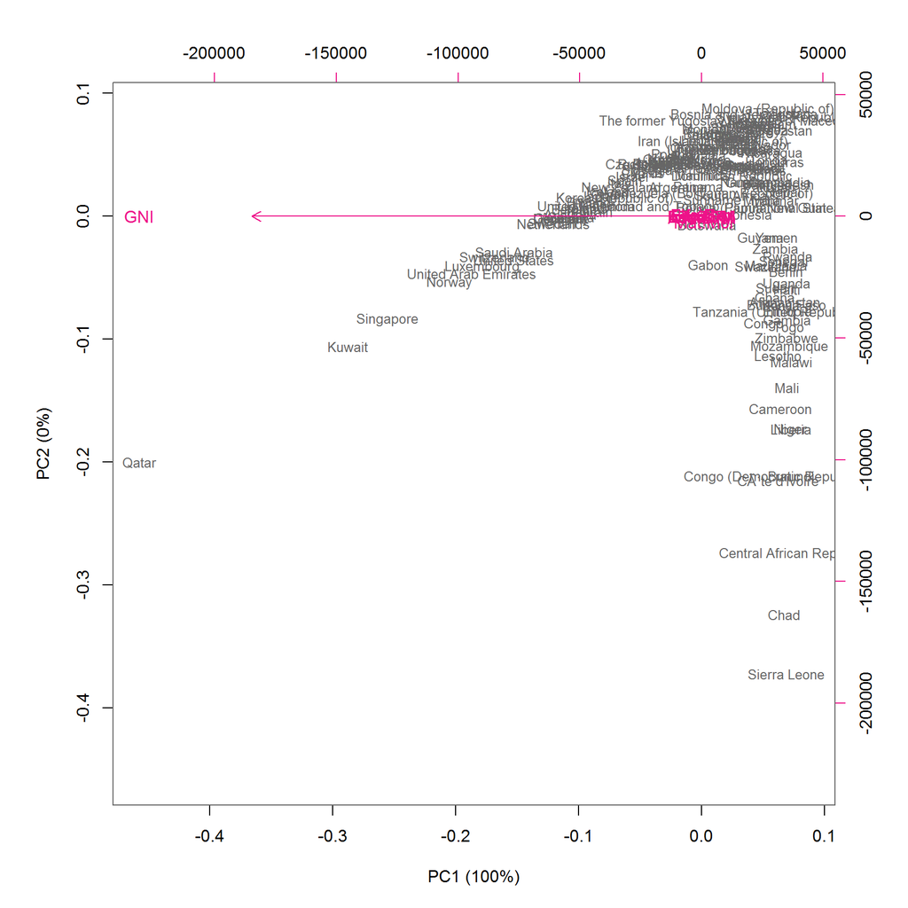

Figure 3. Biplot of PCA of unscaled variables

```r
# create object pc_lab to be used as axis labels
pc_lab <- paste0(names(pca_pr), " (", pca_pr, "%)")

# draw a biplot
biplot(pca_human, cex = c(0.8, 1), col = c("grey40", "deeppink2"), xlab = pc_lab[1], ylab = pc_lab[2])
```

## principal component analysis (PCA) with scaled variables

```r
#Run principal component analysis (PCA)

#standardize datset
human_std <- scale(human)
# perform principal component analysis (with the SVD method)
pca_human_std <- prcomp(human_std)
# the variability captured by the principal components
# create and print out a summary of pca_human
# create and print out a summary of pca_human
s_std <- summary(pca_human_std)
s_std
```

```
## Importance of components:
##                           PC1    PC2     PC3     PC4     PC5     PC6
## Standard deviation     2.0708 1.1397 0.87505 0.77886 0.66196 0.53631
## Proportion of Variance 0.5361 0.1624 0.09571 0.07583 0.05477 0.03595
## Cumulative Proportion  0.5361 0.6984 0.79413 0.86996 0.92473 0.96069
##                            PC7     PC8
## Standard deviation     0.45900 0.32224
## Proportion of Variance 0.02634 0.01298
## Cumulative Proportion  0.98702 1.00000
```

```r
# rounded percentages of variance captured by each PC
pca_pr_std <- round(100*s_std$importance[2,], digits = 1)

# print out the percentages of variance
pca_pr_std
```

```
##  PC1  PC2  PC3  PC4  PC5  PC6  PC7  PC8
## 53.6 16.2  9.6  7.6  5.5  3.6  2.6  1.3
```

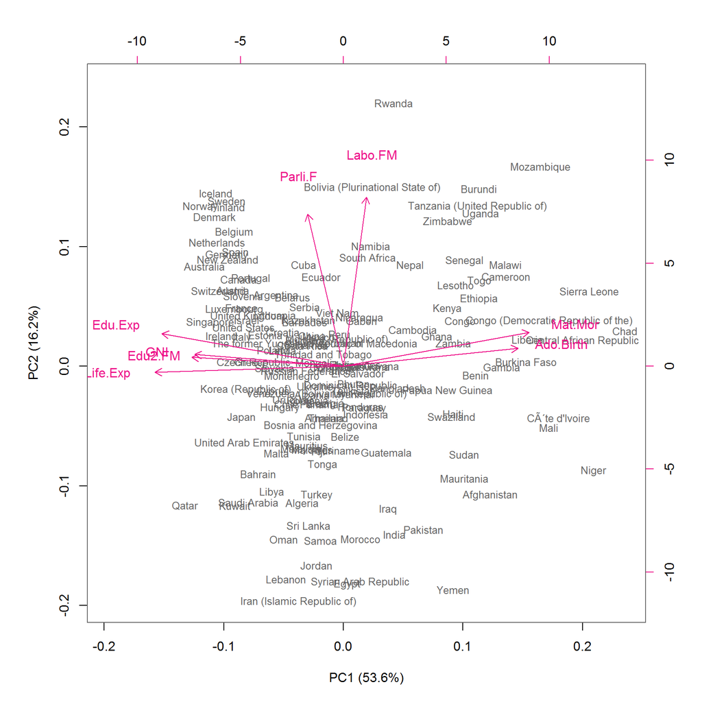

Figure 4. Biplot of PCA of scaled variables

```r
# create object pc_lab to be used as axis labels
pc_lab_std <- paste0(names(pca_pr_std), " (", pca_pr_std, "%)")

# draw a biplot
biplot(pca_human_std, cex = c(0.8, 1), col = c("grey40", "deeppink2"), xlab = pc_lab_std[1], ylab = pc_lab_std[2])
```

## Multiple correspondence analysis (MCA) of categorical values

Loaded the tea dataset from package Factominer. The original datset had 300 obs. of 36 variables, but I selected 6 variables for further analysis (“Tea”, “How”, “how”, “sugar”, “where”, “lunch”). Below you can see the brief exploratioon of the datset. The histogram shows you the groups of each variables and their count.

Then performed MDA, and biplot is shown in figure 5. the first dimension capture 15% of the variance and the second 14% of the variance i the dataset.The further away thevariables in the plot are the more dissimilar they are. Hence;

```r
library(FactoMineR);library(ggplot2);library(dplyr);library(tidyr)

data(tea)
str(tea)
```

```
## 'data.frame':    300 obs. of  36 variables:
##  $ breakfast       : Factor w/ 2 levels "breakfast","Not.breakfast": 1 1 2 2 1 2 1 2 1 1 ...
##  $ tea.time        : Factor w/ 2 levels "Not.tea time",..: 1 1 2 1 1 1 2 2 2 1 ...
##  $ evening         : Factor w/ 2 levels "evening","Not.evening": 2 2 1 2 1 2 2 1 2 1 ...
##  $ lunch           : Factor w/ 2 levels "lunch","Not.lunch": 2 2 2 2 2 2 2 2 2 2 ...
##  $ dinner          : Factor w/ 2 levels "dinner","Not.dinner": 2 2 1 1 2 1 2 2 2 2 ...
##  $ always          : Factor w/ 2 levels "always","Not.always": 2 2 2 2 1 2 2 2 2 2 ...
##  $ home            : Factor w/ 2 levels "home","Not.home": 1 1 1 1 1 1 1 1 1 1 ...
##  $ work            : Factor w/ 2 levels "Not.work","work": 1 1 2 1 1 1 1 1 1 1 ...
##  $ tearoom         : Factor w/ 2 levels "Not.tearoom",..: 1 1 1 1 1 1 1 1 1 2 ...
##  $ friends         : Factor w/ 2 levels "friends","Not.friends": 2 2 1 2 2 2 1 2 2 2 ...
##  $ resto           : Factor w/ 2 levels "Not.resto","resto": 1 1 2 1 1 1 1 1 1 1 ...
##  $ pub             : Factor w/ 2 levels "Not.pub","pub": 1 1 1 1 1 1 1 1 1 1 ...
##  $ Tea             : Factor w/ 3 levels "black","Earl Grey",..: 1 1 2 2 2 2 2 1 2 1 ...
##  $ How             : Factor w/ 4 levels "alone","lemon",..: 1 3 1 1 1 1 1 3 3 1 ...
```

[output cut: 22 more lines]

```r
keep_columns <- c("Tea", "How", "how", "sugar", "where", "lunch")
tea_time <- subset(tea, select=c("Tea", "How", "how", "sugar", "where", "lunch"))

summary(tea_time)
```

```
##         Tea         How                      how           sugar
##  black    : 74   alone:195   tea bag           :170   No.sugar:155
##  Earl Grey:193   lemon: 33   tea bag+unpackaged: 94   sugar   :145
##  green    : 33   milk : 63   unpackaged        : 36
##                  other:  9
##                   where           lunch
##  chain store         :192   lunch    : 44
##  chain store+tea shop: 78   Not.lunch:256
##  tea shop            : 30
##
```

```r
str(tea_time)
```

```
## 'data.frame':    300 obs. of  6 variables:
##  $ Tea  : Factor w/ 3 levels "black","Earl Grey",..: 1 1 2 2 2 2 2 1 2 1 ...
##  $ How  : Factor w/ 4 levels "alone","lemon",..: 1 3 1 1 1 1 1 3 3 1 ...
##  $ how  : Factor w/ 3 levels "tea bag","tea bag+unpackaged",..: 1 1 1 1 1 1 1 1 2 2 ...
##  $ sugar: Factor w/ 2 levels "No.sugar","sugar": 2 1 1 2 1 1 1 1 1 1 ...
##  $ where: Factor w/ 3 levels "chain store",..: 1 1 1 1 1 1 1 1 2 2 ...
##  $ lunch: Factor w/ 2 levels "lunch","Not.lunch": 2 2 2 2 2 2 2 2 2 2 ...
```

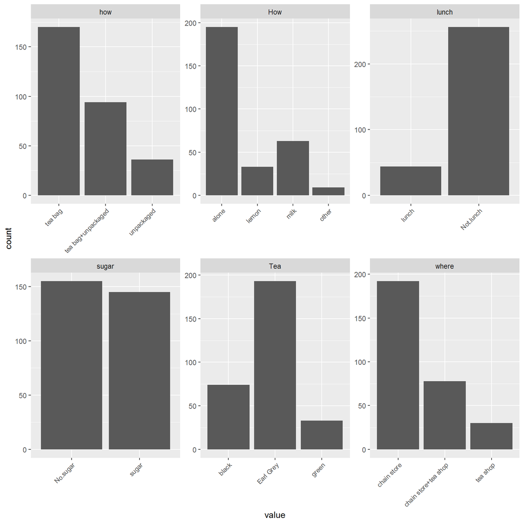

```r
gather(tea_time) %>% ggplot(aes(value)) + facet_wrap("key", scales = "free") + geom_bar() + theme(axis.text.x = element_text(angle = 45, hjust = 1, size = 8))
```

```r
# multiple correspondence analysis
mca <- MCA(tea_time, graph = FALSE)

# summary of the mode
summary(mca)
```

```
##
## Call:
## MCA(X = tea_time, graph = FALSE)
##
##
## Eigenvalues
##                        Dim.1   Dim.2   Dim.3   Dim.4   Dim.5   Dim.6
## Variance               0.279   0.261   0.219   0.189   0.177   0.156
## % of var.             15.238  14.232  11.964  10.333   9.667   8.519
## Cumulative % of var.  15.238  29.471  41.435  51.768  61.434  69.953
##                        Dim.7   Dim.8   Dim.9  Dim.10  Dim.11
## Variance               0.144   0.141   0.117   0.087   0.062
## % of var.              7.841   7.705   6.392   4.724   3.385
## Cumulative % of var.  77.794  85.500  91.891  96.615 100.000
##
## Individuals (the 10 first)
##                       Dim.1    ctr   cos2    Dim.2    ctr   cos2    Dim.3
## 1                  | -0.298  0.106  0.086 | -0.328  0.137  0.105 | -0.327
## 2                  | -0.237  0.067  0.036 | -0.136  0.024  0.012 | -0.695
## 3                  | -0.369  0.162  0.231 | -0.300  0.115  0.153 | -0.202
## 4                  | -0.530  0.335  0.460 | -0.318  0.129  0.166 |  0.211
## 5                  | -0.369  0.162  0.231 | -0.300  0.115  0.153 | -0.202
## 6                  | -0.369  0.162  0.231 | -0.300  0.115  0.153 | -0.202
## 7                  | -0.369  0.162  0.231 | -0.300  0.115  0.153 | -0.202
## 8                  | -0.237  0.067  0.036 | -0.136  0.024  0.012 | -0.695
## 9                  |  0.143  0.024  0.012 |  0.871  0.969  0.435 | -0.067
## 10                 |  0.476  0.271  0.140 |  0.687  0.604  0.291 | -0.650
##                       ctr   cos2
## 1                   0.163  0.104 |
## 2                   0.735  0.314 |
## 3                   0.062  0.069 |
## 4                   0.068  0.073 |
## 5                   0.062  0.069 |
## 6                   0.062  0.069 |
## 7                   0.062  0.069 |
## 8                   0.735  0.314 |
## 9                   0.007  0.003 |
## 10                  0.643  0.261 |
##
## Categories (the 10 first)
```

[output cut: 16 more lines]

```
## lemon                0.035   3.226 |   1.329  14.771   0.218   8.081 |
## milk                 0.020   2.422 |   0.013   0.003   0.000   0.116 |
## other                0.102   5.534 |  -2.524  14.526   0.197  -7.676 |
## tea bag              0.161  -6.941 |  -0.065   0.183   0.006  -1.287 |
## tea bag+unpackaged   0.478  11.956 |   0.019   0.009   0.000   0.226 |
## unpackaged           0.141  -6.482 |   0.257   0.602   0.009   1.640 |
##
## Categorical variables (eta2)
##                      Dim.1 Dim.2 Dim.3
## Tea                | 0.126 0.108 0.410 |
## How                | 0.076 0.190 0.394 |
## how                | 0.708 0.522 0.010 |
## sugar              | 0.065 0.001 0.336 |
## where              | 0.702 0.681 0.055 |
## lunch              | 0.000 0.064 0.111 |
```

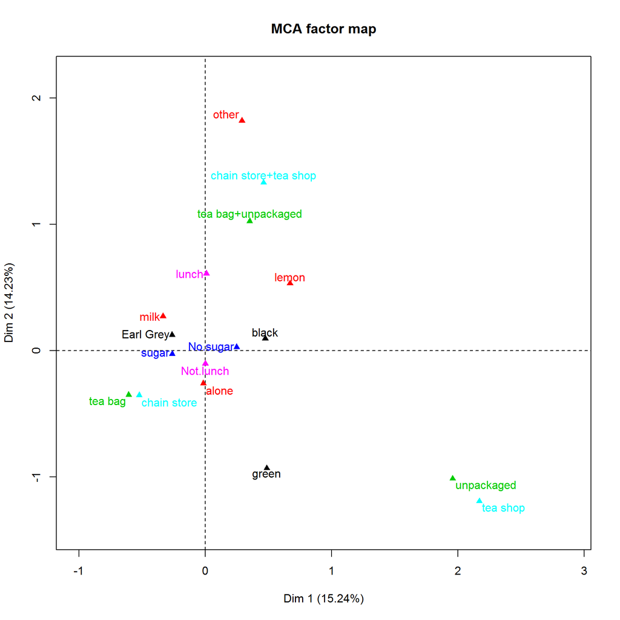

Figure 5, Biplot of MDS

```r
# visualize MCA
plot(mca, invisible=c("ind"), habillage = "quali")
```